# Price prediction algorithms

# Introduction

It contains different algorithms to predict the price of diamond

# Prepare Data

Call the necessary libraries for the project.

```r
library(randomForest)
library(tidyverse)
library(dplyr)
library(gvlma)
library(caret)
library(Metrics)
library(MLmetrics)
library(plot3D)
library(plot3Drgl)
library(rgl)
library(corrplot)
library(caTools)
library(ROCR)
library(party)
```

Then we call the diamond data

```r
dt <- read.csv("diamonds.csv")
dt=dt[1:20000,]
dt
```

```
##         X carat       cut color clarity depth table price    x    y    z
## 1       1  0.23     Ideal     E     SI2  61.5  55.0   326 3.95 3.98 2.43
## 2       2  0.21   Premium     E     SI1  59.8  61.0   326 3.89 3.84 2.31
## 3       3  0.23      Good     E     VS1  56.9  65.0   327 4.05 4.07 2.31
## 4       4  0.29   Premium     I     VS2  62.4  58.0   334 4.20 4.23 2.63
## 5       5  0.31      Good     J     SI2  63.3  58.0   335 4.34 4.35 2.75
## 6       6  0.24 Very Good     J    VVS2  62.8  57.0   336 3.94 3.96 2.48
## 7       7  0.24 Very Good     I    VVS1  62.3  57.0   336 3.95 3.98 2.47
## 8       8  0.26 Very Good     H     SI1  61.9  55.0   337 4.07 4.11 2.53
## 9       9  0.22      Fair     E     VS2  65.1  61.0   337 3.87 3.78 2.49
## 10     10  0.23 Very Good     H     VS1  59.4  61.0   338 4.00 4.05 2.39
## 11     11  0.30      Good     J     SI1  64.0  55.0   339 4.25 4.28 2.73
## 12     12  0.23     Ideal     J     VS1  62.8  56.0   340 3.93 3.90 2.46
## 13     13  0.22   Premium     F     SI1  60.4  61.0   342 3.88 3.84 2.33
## 14     14  0.31     Ideal     J     SI2  62.2  54.0   344 4.35 4.37 2.71
```

[output cut: 9077 more lines]

- price price in US dollars ($326–$18,823)
- carat weight of the diamond (0.2–5.01)
- cut quality of the cut (Fair, Good, Very Good, Premium, Ideal)
- color diamond colour, from J (worst) to D (best)
- clarity a measurement of how clear the diamond is (I1 (worst), SI2, SI1, VS2, VS1, VVS2, VVS1, IF (best))
- x length in mm (0–10.74)
- y width in mm (0–58.9)
- z depth in mm (0–31.8)
- depth total depth percentage = z / mean(x, y) = 2 * z / (x + y) (43–79)
- table width of top of diamond relative to widest point (43–95)

```r
#Identify Missing Values
sapply(dt, function(x) sum(is.na(x)))
```

```
##       X   carat     cut   color clarity   depth   table   price       x       y
##       0       0       0       0       0       0       0       0       0       0
##       z
##       0
```

```r
dt = dt[,!(names(dt) %in% c("...1"))]

cut_chr <- c("Fair", "Good", "Very Good", "Premium", "Ideal")
aux <- 1:length(cut_chr)
dt$cut <-aux[match(dt$cut, cut_chr)]

color_chr <- c("J","I","H", "G", "F", "E", "D")
aux <- 1:length(color_chr)
dt$color <- aux[match(dt$color, color_chr)]

clarity_chr <- c("I1", "SI2", "SI1", "VS2", "VS1","VVS2","VVS1","IF")
aux <- 1:length(clarity_chr)
dt$clarity <-aux[match(dt$clarity, clarity_chr)]
head(dt)
```

```
##   X carat cut color clarity depth table price    x    y    z
## 1 1  0.23   5     6       2  61.5    55   326 3.95 3.98 2.43
## 2 2  0.21   4     6       3  59.8    61   326 3.89 3.84 2.31
## 3 3  0.23   2     6       5  56.9    65   327 4.05 4.07 2.31
## 4 4  0.29   4     2       4  62.4    58   334 4.20 4.23 2.63
## 5 5  0.31   2     1       2  63.3    58   335 4.34 4.35 2.75
## 6 6  0.24   3     1       6  62.8    57   336 3.94 3.96 2.48
```

# Simple regresion

Now we are going to analyze what variable is most significant in the price prediction.

```r
for(i in colnames(dt)) {
  if(i=="price"){
  next
  }
  cor <- cor.test(dt$price,dt[[i]])
  model <- lm(dt$price ~ dt[[i]])
  sum <- summary(model)
  print(paste0("correlation price ",i," ",cor$estimate, " linear regresion error ", sum$adj.r.squared))
}
```

```
## [1] "correlation price X 0.700164444473535 linear regresion error 0.490204758268295"
## [1] "correlation price carat 0.834154037679871 linear regresion error 0.695797747704474"
## [1] "correlation price cut 0.0107725656071423 linear regresion error 6.60489722488222e-05"
## [1] "correlation price color -0.0997179860410812 linear regresion error 0.00989416897314976"
## [1] "correlation price clarity -0.0259868041038646 linear regresion error 0.000625342756108371"
## [1] "correlation price depth -0.0068212861251565 linear regresion error -3.47272937117893e-06"
## [1] "correlation price table 0.0510980402347644 linear regresion error 0.00256113527887403"
## [1] "correlation price x 0.839591396119093 linear regresion error 0.704898956647251"
## [1] "correlation price y 0.845248749033089 linear regresion error 0.714431168586474"
## [1] "correlation price z 0.823632347602497 linear regresion error 0.678354160921092"
```

These values can be represented in the following table.

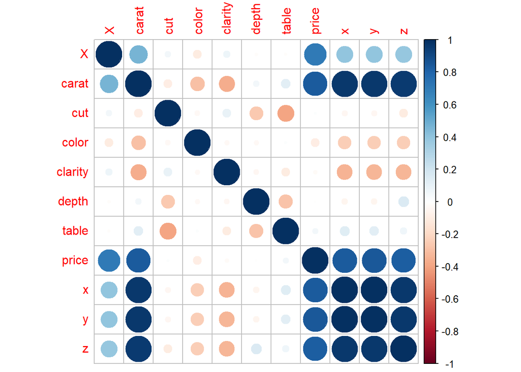

```r
corrplot(cor(dt), method='circle')
```

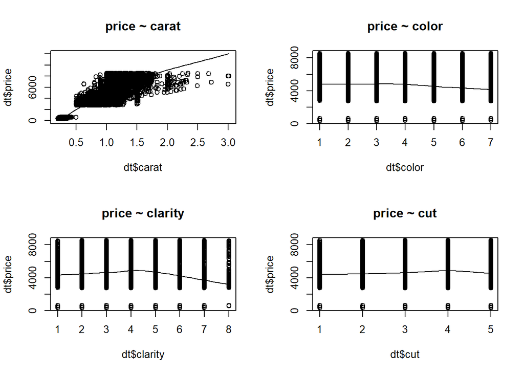

```r
par(mfrow=c(2,2))
scatter.smooth(x=dt$carat, y=dt$price, main="price ~ carat")
scatter.smooth(x=dt$color, y=dt$price, main="price ~ color")
scatter.smooth(x=dt$clarity, y=dt$price, main="price ~ clarity")
scatter.smooth(x=dt$cut, y=dt$price, main="price ~ cut")
```

visualization

```r
library(ggplot2)
```

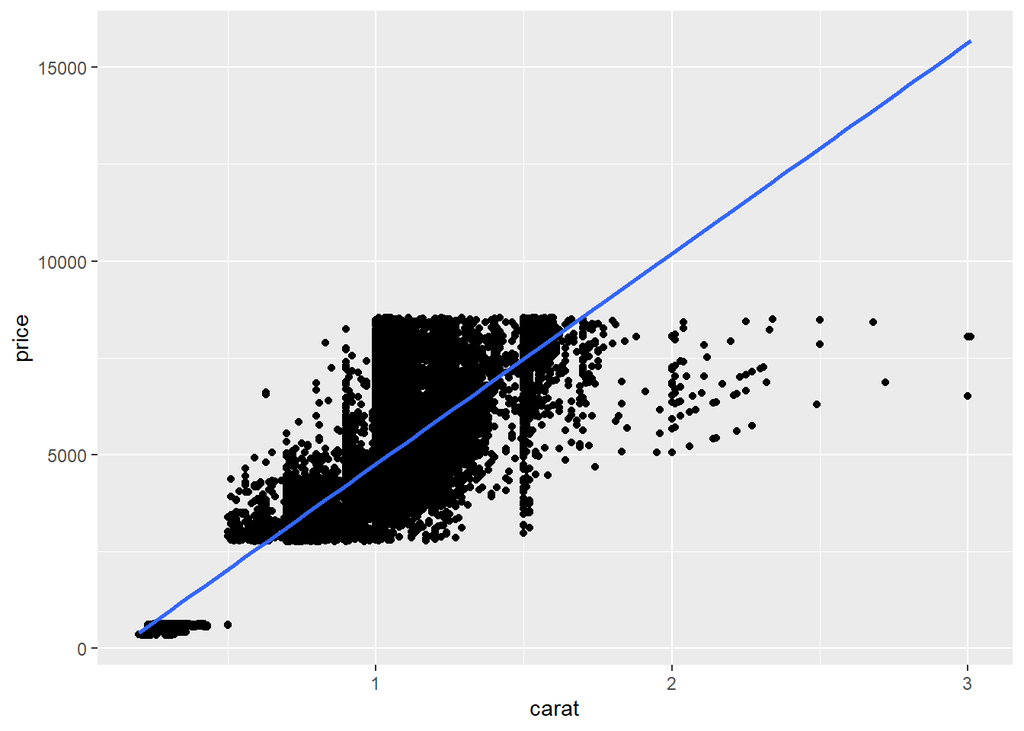

```r
ggplot(dt, aes(x = carat, y = price)) +
  geom_point() +
  geom_smooth(method = "lm", se = FALSE)
```

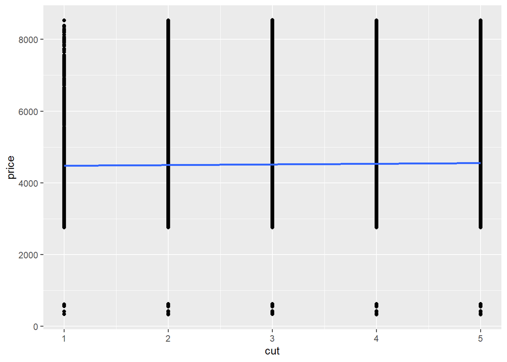

```r
ggplot(dt, aes(x = cut, y = price)) +
  geom_point() +
  geom_smooth(method = "lm", se = FALSE)
```

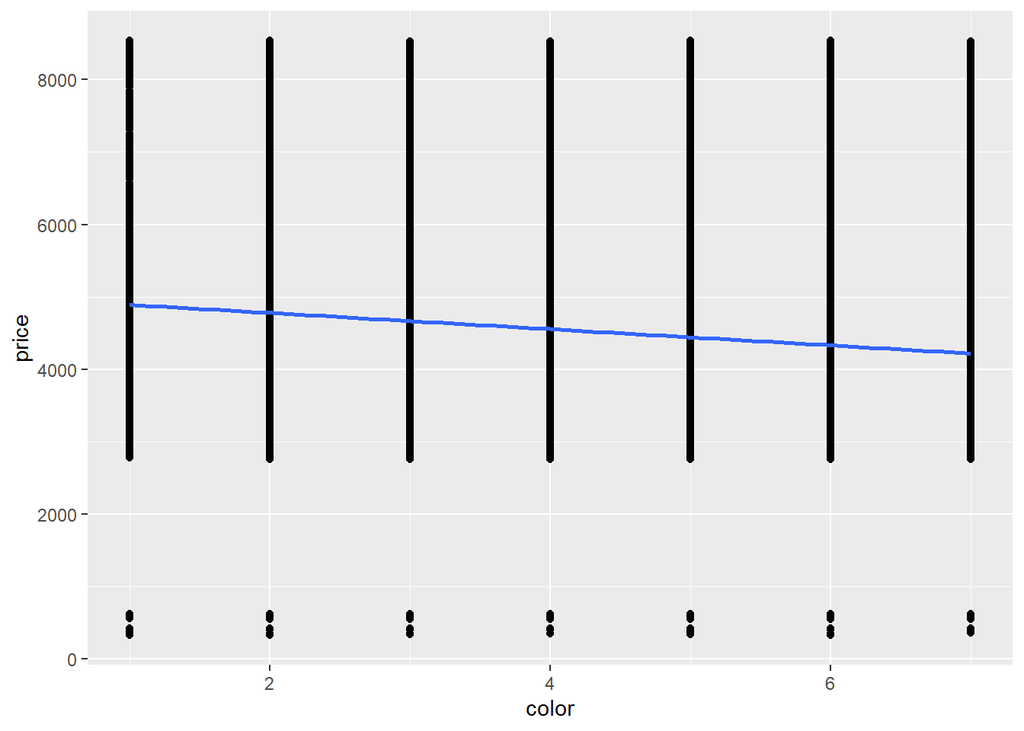

```r
ggplot(dt, aes(x = color, y = price)) +
  geom_point() +
  geom_smooth(method = "lm", se = FALSE)
```

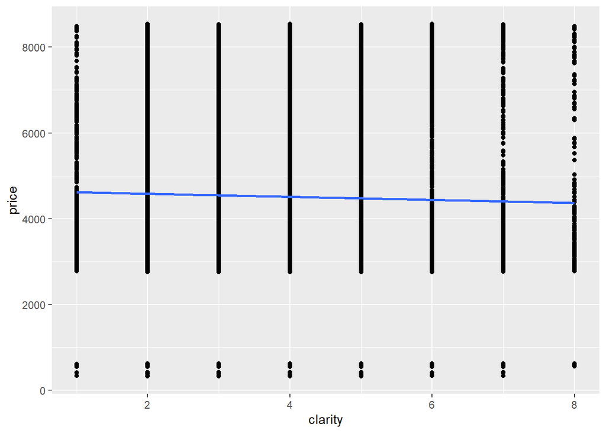

```r
ggplot(dt, aes(x = clarity, y = price)) +
  geom_point() +
  geom_smooth(method = "lm", se = FALSE)
```

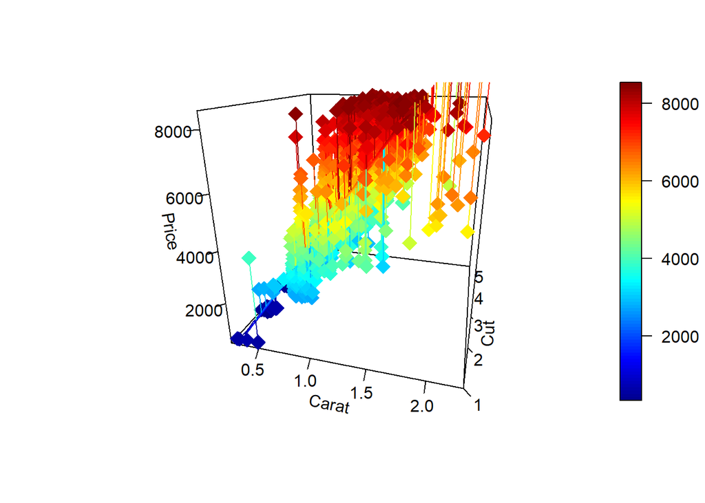

```r
dt <- sample_n(dt, 5000)
z<-dt$price
y<-dt$cut
x<-dt$carat
objr<-lm(z ~ x+y)
grid.lines = 50
x.pred <- seq(min(x), max(x), length.out = grid.lines)
y.pred <- seq(min(y), max(y), length.out = grid.lines)
xy <- expand.grid( x = x.pred, y = y.pred)
z.pred <- matrix(predict(objr, newdata = xy),
                 nrow = grid.lines, ncol = grid.lines)
fitpoints <- predict(objr)
scatter3D(x, y, z, pch = 18, cex = 2,
          theta = 15, phi = 20, ticktype = "detailed",
          xlab = "Carat", ylab = "Cut", zlab = "Price",
          surf = list(x = x.pred, y = y.pred, z = z.pred,
                      facets = NA, fit = fitpoints), main = "")
```

```r
plotrgl()
```

Prepare the partition into 70% train 30% test.

```r
partition <- createDataPartition(y =dt$price,p = 0.7,list = FALSE)
dt_train <- dt[partition,]
Test <- dt[-partition,]
```

Create de different model using:

- LM: Fitting Linear
- KNN: K-nearest neighbors
- RF: Random forest regression

```r
#Control using cross validation

ctrol <- trainControl(method="cv",number=10)
```

```r
# LM
mod  <- train(price~.,data=dt_train,method="lm",trControl=ctrol)
```

```r
# knn
values_knn <- expand.grid(k = c(1,3,5))
mod_knn  <- train(price~.,data=dt_train,method="knn",trControl=ctrol,tuneGrid=values_knn)
```

```r
# Rf
mod_rf  <- train(price~.,data=dt_train,method="rf",tunelenght=6,trControl=ctrol)

# Results
print(paste0("LM - RMSE: ",rmse(Test$price,predict(mod,Test))," R2: ", R2_Score(Test$price , predict(mod,Test))))
```

```
## [1] "LM - RMSE: 501.682975211879 R2: 0.928827722018844"
```

```r
print(paste0("KNN - RMSE: ",rmse(Test$price,predict(mod_knn,Test))," R2: ", R2_Score(Test$price , predict(mod_knn,Test))))
```

```
## [1] "KNN - RMSE: 520.328000545907 R2: 0.927341045871387"
```

```r
print(paste0("RF - RMSE: ",rmse(Test$price,predict(mod_rf,Test))," R2: ", R2_Score(Test$price , predict(mod_rf,Test))))
```

```
## [1] "RF - RMSE: 60.3306502964279 R2: 0.999042770782282"
```

# Comparison real vs predicted

```r
aux <- data.frame("a"=Test$price, "b" = predict(mod_rf,Test),"c"=predict(mod_knn,Test))
colnames(aux) <- c("real_price", "predicted_RF", "predicted_knn")
head(aux,20)
```

```
##    real_price predicted_RF predicted_knn
## 5        3726    3723.8066          3726
## 16       4497    4496.9551          4497
## 23       4347    4347.8877          4347
## 25       7204    7208.6966          7207
## 29       4256    4254.3959          4256
## 31       7479    7476.7460          7477
## 32       7459    7459.1672          7459
## 36       5778    5776.2275          5777
## 39       3677    3679.6513          3676
## 43        558     557.6333           558
## 44        567     562.2415           567
## 45       5621    5621.9481          5622
## 47       3780    3782.7744          3780
## 51        408     430.5915           407
## 55       4432    4432.8067          4432
## 57       4011    4017.6408          4011
## 59       5798    5795.4281          5795
## 60       7468    7462.9825           616
## 66       4249    4250.2516          4249
## 68       5443    5443.3154          5443
```

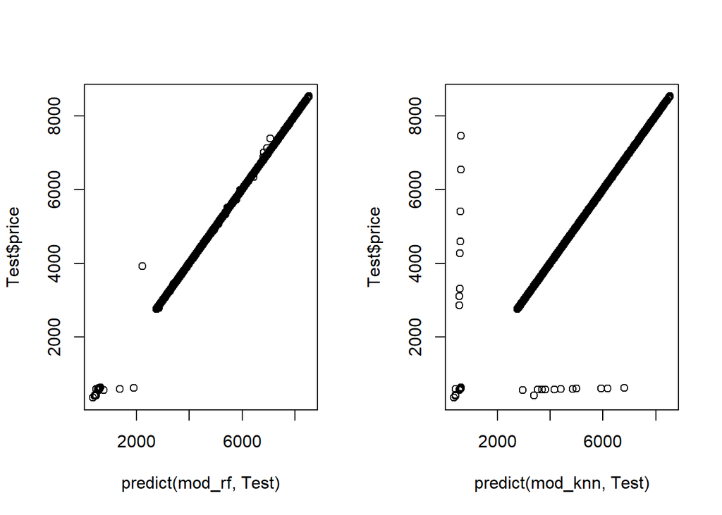

```r
par(mfrow=c(1,2))
plot(predict(mod_rf,Test),Test$price)
plot(predict(mod_knn,Test),Test$price)
```